# tidyqaunt Package 연습

## tidyquant 패키지

- quantmod 등 주식 분석을 주 목적으로 하는 중요 함수를 제공하는 패키지.
- tidy data 개념을 활용한 데이터 핸들링, ggplot 과 연계된 차트그리기.
- 야후, 구글 및 독자적인 데이터 소스로 부터 필요한 데이터 손쉽게 가져오기.
- 성능 분석 함수들이 포함됨.

### zoo, xts, quantmod, TTR, PerformanceAnalytics의 5개의 패키지 내의 함수를 지원

```r
tq_transmute_fun_options() %>% str
```

```
## List of 5
##  $ zoo                 : chr [1:14] "rollapply" "rollapplyr" "rollmax" "rollmax.default" ...
##  $ xts                 : chr [1:27] "apply.daily" "apply.monthly" "apply.quarterly" "apply.weekly" ...
##  $ quantmod            : chr [1:25] "allReturns" "annualReturn" "ClCl" "dailyReturn" ...
##  $ TTR                 : chr [1:62] "adjRatios" "ADX" "ALMA" "aroon" ...
##  $ PerformanceAnalytics: chr [1:7] "Return.annualized" "Return.annualized.excess" "Return.clean" "Return.cumulative" ...
```

#### zoo Functionality

롤링마진 관련하여 기능을 작용하는 일반적인 기능을 하는 함수들

```r
tq_transmute_fun_options()$zoo
```

```
##  [1] "rollapply"          "rollapplyr"         "rollmax"
##  [4] "rollmax.default"    "rollmaxr"           "rollmean"
##  [7] "rollmean.default"   "rollmeanr"          "rollmedian"
## [10] "rollmedian.default" "rollmedianr"        "rollsum"
## [13] "rollsum.default"    "rollsumr"
```

#### xts Functionality

시계열 데이터를 사용하기 위한 함수들

```r
tq_transmute_fun_options()$xts
```

```
##  [1] "apply.daily"     "apply.monthly"   "apply.quarterly" "apply.weekly"
##  [5] "apply.yearly"    "diff.xts"        "lag.xts"         "period.apply"
##  [9] "period.max"      "period.min"      "period.prod"     "period.sum"
## [13] "periodicity"     "to_period"       "to.daily"        "to.hourly"
## [17] "to.minutes"      "to.minutes10"    "to.minutes15"    "to.minutes3"
## [21] "to.minutes30"    "to.minutes5"     "to.monthly"      "to.period"
## [25] "to.quarterly"    "to.weekly"       "to.yearly"
```

#### quantmod Functionality

외부에서 가져오는 금융 데이터 처리, lag 등 금융 데이터 관리 도구

```r
tq_transmute_fun_options()$quantmod
```

```
##  [1] "allReturns"      "annualReturn"    "ClCl"            "dailyReturn"
##  [5] "Delt"            "HiCl"            "Lag"             "LoCl"
##  [9] "LoHi"            "monthlyReturn"   "Next"            "OpCl"
## [13] "OpHi"            "OpLo"            "OpOp"            "periodReturn"
## [17] "quarterlyReturn" "seriesAccel"     "seriesDecel"     "seriesDecr"
## [21] "seriesHi"        "seriesIncr"      "seriesLo"        "weeklyReturn"
## [25] "yearlyReturn"
```

#### TTR Functionality

기술 거래 규칙(Technical Trading Rules)을 구성하는 기능을 제공

```r
tq_transmute_fun_options()$TTR
```

```
##  [1] "adjRatios"          "ADX"                "ALMA"
##  [4] "aroon"              "ATR"                "BBands"
##  [7] "CCI"                "chaikinAD"          "chaikinVolatility"
## [10] "CLV"                "CMF"                "CMO"
## [13] "DEMA"               "DonchianChannel"    "DPO"
## [16] "DVI"                "EMA"                "EMV"
## [19] "EVWMA"              "GMMA"               "growth"
## [22] "HMA"                "KST"                "lags"
## [25] "MACD"               "MFI"                "momentum"
## [28] "OBV"                "PBands"             "ROC"
## [31] "rollSFM"            "RSI"                "runCor"
## [34] "runCov"             "runMAD"             "runMax"
## [37] "runMean"            "runMedian"          "runMin"
## [40] "runPercentRank"     "runSD"              "runSum"
## [43] "runVar"             "SAR"                "SMA"
## [46] "SMI"                "SNR"                "stoch"
## [49] "TDI"                "TRIX"               "ultimateOscillator"
## [52] "VHF"                "VMA"                "volatility"
## [55] "VWAP"               "VWMA"               "wilderSum"
## [58] "williamsAD"         "WMA"                "WPR"
## [61] "ZigZag"             "ZLEMA"
```

#### PerformanceAnalytics Functionality

assets, contraint 및 objectives 를 분리하고 모듈화하기 위한 포트폴리오 분석, 수익률 계산에 특화된 패키지

```r
tq_transmute_fun_options()$PerformanceAnalytics
```

```
## [1] "Return.annualized"        "Return.annualized.excess"
## [3] "Return.clean"             "Return.cumulative"
## [5] "Return.excess"            "Return.Geltner"
## [7] "zerofill"
```

## Example 연습

https://cran.r-project.org/web/packages/tidyquant/vignettes/TQ02-quant-integrations-in-tidyquant.html

### DATA : FANG

**FANG** ( FB: Facebook, AMZN : Amazon, NELX : Netflix, GOOGL : google )  
2013년 ~ 2016년 까지의 주식 데이터 In USD

- symbol : 회사명
- date : 거래 날짜
- open : 시가, 시작 주가
- high : 고가, 거래날 가장 높은 주가
- low : 저가, 거래날 가장 낮은 주가
- close : 종가, 거래 종료 주가
- volume : 거래량
- adjusted : 조정된 주가

```r
data("FANG")

head(FANG)
```

```
## # A tibble: 6 x 8
##   symbol date        open  high   low close    volume adjusted
##   <chr>  <date>     <dbl> <dbl> <dbl> <dbl>     <dbl>    <dbl>
## 1 FB     2013-01-02  27.4  28.2  27.4  28    69846400     28
## 2 FB     2013-01-03  27.9  28.5  27.6  27.8  63140600     27.8
## 3 FB     2013-01-04  28.0  28.9  27.8  28.8  72715400     28.8
## 4 FB     2013-01-07  28.7  29.8  28.6  29.4  83781800     29.4
## 5 FB     2013-01-08  29.5  29.6  28.9  29.1  45871300     29.1
## 6 FB     2013-01-09  29.7  30.6  29.5  30.6 104787700     30.6
```

### Example 1: Use quantmod periodReturn to Convert Prices to Returns

The `quantmod::periodReturn()` function generates returns by periodicity.  
주기별로 값을 타입별 계산하여 리턴값 반환

- Period Return Functions:
  - Get the arithmetic or logarithmic returns for various periodicity, which include daily, weekly, monthly, quarterly, and yearly.
  - Form: periodReturn(x, period = ‘monthly’, subset = NULL, type = ‘arithmetic’, leading = TRUE, …)

#### Example 1A. Getting and Charting Annual Returns

기업별로 연도별(period=yearly)의 조정된 주가(select = adjusted) 에 대한 연도 주기별 리턴값  
type = “arithmetic” 의 산술 연산

```r
FANG_anuual_returns <- FANG %>%
  group_by(symbol) %>%
  tq_transmute(select = adjusted,
               mutate_fun = periodReturn, #yearly.returns : 생성된 column 명
               period = "yearly",
               type = "arithmetic")

FANG_anuual_returns
```

```
## # A tibble: 16 x 3
## # Groups:   symbol [4]
##    symbol date       yearly.returns
##    <chr>  <date>              <dbl>
##  1 FB     2013-12-31         0.952
##  2 FB     2014-12-31         0.428
##  3 FB     2015-12-31         0.341
##  4 FB     2016-12-30         0.0993
##  5 AMZN   2013-12-31         0.550
##  6 AMZN   2014-12-31        -0.222
##  7 AMZN   2015-12-31         1.18
##  8 AMZN   2016-12-30         0.109
##  9 NFLX   2013-12-31         3.00
## 10 NFLX   2014-12-31        -0.0721
## 11 NFLX   2015-12-31         1.34
## 12 NFLX   2016-12-30         0.0824
## 13 GOOG   2013-12-31         0.550
## 14 GOOG   2014-12-31        -0.0597
## 15 GOOG   2015-12-31         0.442
## 16 GOOG   2016-12-30         0.0171
```

**ggplot2 패키지를 활용한 차트 그리기**

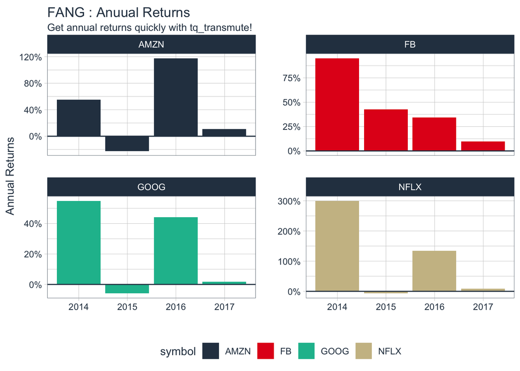

```r
FANG_anuual_returns %>%
  ggplot(aes(x = date, y = yearly.returns, fill = symbol)) +
  geom_col()+
  geom_hline(yintercept = 0, color = palette_light()[[1]]) +
  scale_y_continuous(labels = scales::percent ) +
  labs ( title = "FANG : Anuual Returns",
         subtitle = "Get annual returns quickly with tq_transmute!",
         y = "Annual Returns", x = "")+
  facet_wrap(~ symbol, ncol=2, scales = "free_y") +
  theme_tq()+
  scale_fill_tq()
```

**연도별 조정 주가 그래프를 통해 확인 가능한 결과**

- 페이스북, 아마존, 넷플릭스, 구글 모두 2013년, 2015년 긍정적.
- 페이스북은 2013년부터 0% 이상을 유지하고 있으나 그 값이 계속 하락세.
- 그 외 아마존, 넷플릭스, 구글은 2013년 부터 2016년 까지 4년간 비슷한 양상.

#### Example 1B. Getting Daily Log Returns

기업별로 일일(period = “daily”) 조정 주가 (select = adjusted) 에 대한 주기별 로그(type= “log”) 리턴값

```r
FANG_daily_log_returns <- FANG %>%
  group_by(symbol) %>%
  tq_transmute( select = adjusted ,
                mutate_fun = periodReturn,
                period = "daily",
                type = "log")
                #col_renames = "" : 임의로 칼럼 이름 지정 가능
FANG_daily_log_returns
```

```
## # A tibble: 4,032 x 3
## # Groups:   symbol [4]
##    symbol date       daily.returns
##    <chr>  <date>             <dbl>
##  1 FB     2013-01-02       0
##  2 FB     2013-01-03      -0.00825
##  3 FB     2013-01-04       0.0350
##  4 FB     2013-01-07       0.0227
##  5 FB     2013-01-08      -0.0123
##  6 FB     2013-01-09       0.0513
##  7 FB     2013-01-10       0.0229
##  8 FB     2013-01-11       0.0133
##  9 FB     2013-01-14      -0.0246
## 10 FB     2013-01-15      -0.0278
## # … with 4,022 more rows
```

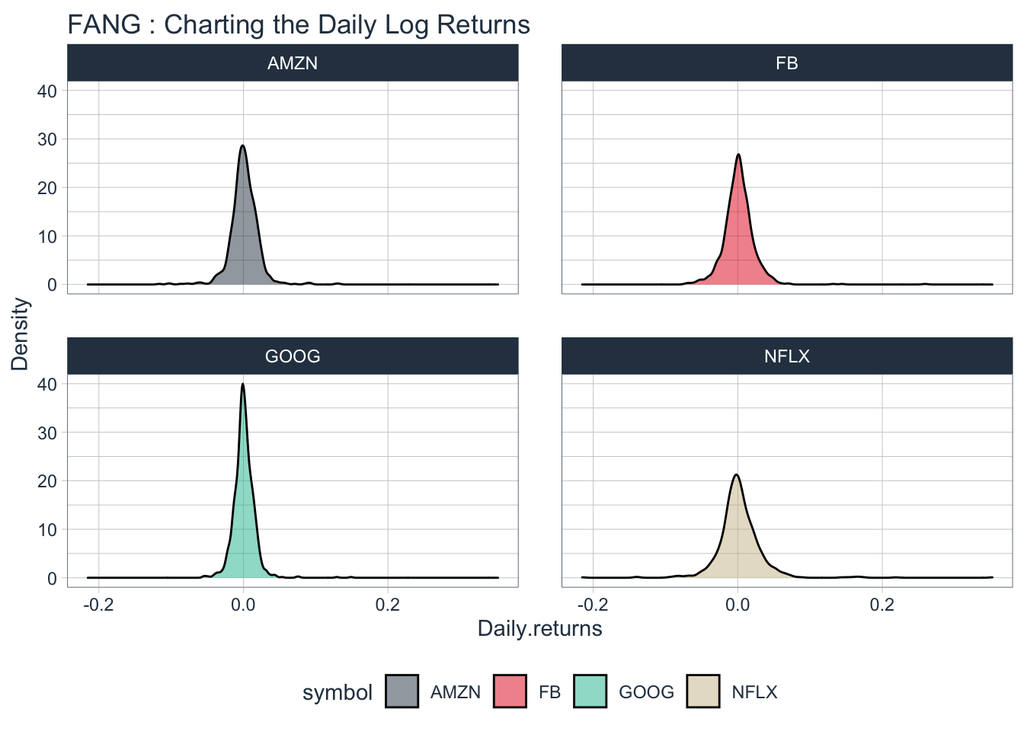

```r
FANG_daily_log_returns %>%
  ggplot(aes(x = daily.returns, fill = symbol))+
  geom_density(alpha = 0.5) +
  labs(title = "FANG : Charting the Daily Log Returns",
       x = "Daily.returns", y = "Density")+
  theme_tq()+
  scale_fill_tq()+
  facet_wrap(~ symbol, ncol=2)
```

조정주가로 일별 로그값 계산했을 대 구글(GOOG)이 가장 높다는 것을 알 수 있음.  
일일 로그값 순위 : 구글(GOOG) > 아마존(AMZN) > 페이스북(FB) > 넷플릭스(NFLX)

### Example 2: Use xts `to.period` to Change the Periodicity from Daily to Monthly

The `xts::to.period` function is used for periodicity aggregation (converting from a lower level periodicity to a higher level such as minutes to hours or months to years).  
낮은 수준의 주기에서 높은 수준의 주기로 변경하기 위해 사용되는 함수  
월별 주기성을 계산하기 위해 to.period , period = “months” 활용

```r
FANG %>%
  group_by(symbol) %>%
  tq_transmute(select = open:volume,
               mutate_fun = to.period,
               period = "months")
```

```
## # A tibble: 192 x 7
## # Groups:   symbol [4]
##    symbol date        open  high   low close    volume
##    <chr>  <date>     <dbl> <dbl> <dbl> <dbl>     <dbl>
##  1 FB     2013-01-31  29.2  31.5  28.7  31.0 190744900
##  2 FB     2013-02-28  26.8  27.3  26.3  27.2  83027800
##  3 FB     2013-03-28  26.1  26.2  25.5  25.6  28585700
##  4 FB     2013-04-30  27.1  27.8  27.0  27.8  36245700
##  5 FB     2013-05-31  24.6  25.0  24.3  24.4  35925000
##  6 FB     2013-06-28  24.7  25.0  24.4  24.9  96778900
##  7 FB     2013-07-31  38.0  38.3  36.3  36.8 154828700
##  8 FB     2013-08-30  42.0  42.3  41.1  41.3  67735100
##  9 FB     2013-09-30  50.1  51.6  49.8  50.2 100095000
## 10 FB     2013-10-31  47.2  52    46.5  50.2 248809000
## # … with 182 more rows
```

#### With Periodity Aggregation : 일일 주기성 집계

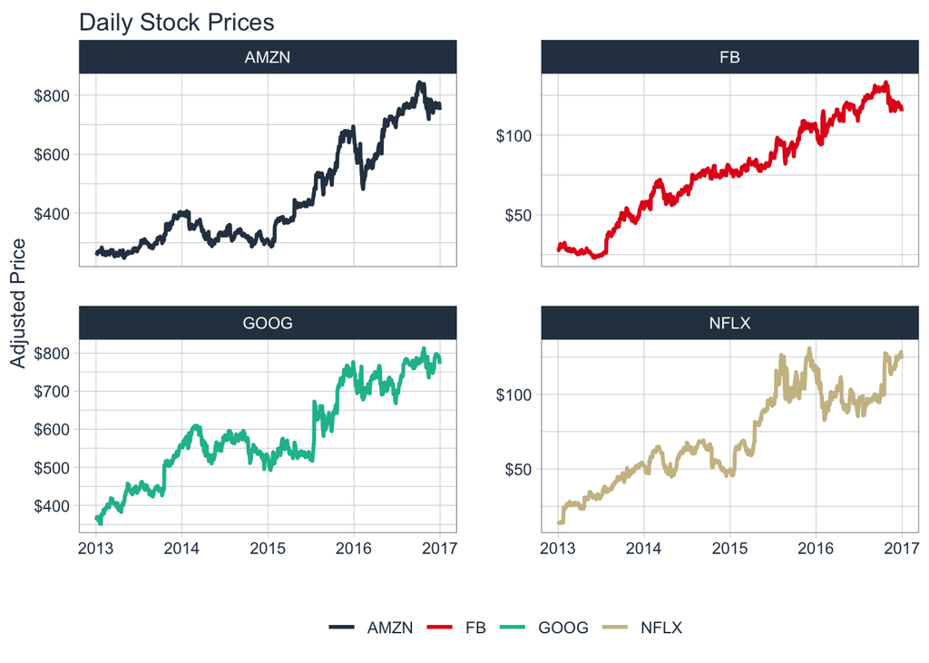

```r
FANG_daily <- FANG %>%
  group_by(symbol)

FANG_daily %>%
  ggplot(aes(x = date, y = adjusted, color= symbol)) +
  geom_line(size =1) +
  labs(title = "Daily Stock Prices",
       x = "", y = "Adjusted Price", color="")+
  facet_wrap (~ symbol, ncol=2, scales = "free_y")+
  scale_y_continuous(labels = scales::dollar)+
  theme_tq()+
  scale_color_tq()
```

#### With Monthly Periodity Aggregation : 월별 주기성 집계

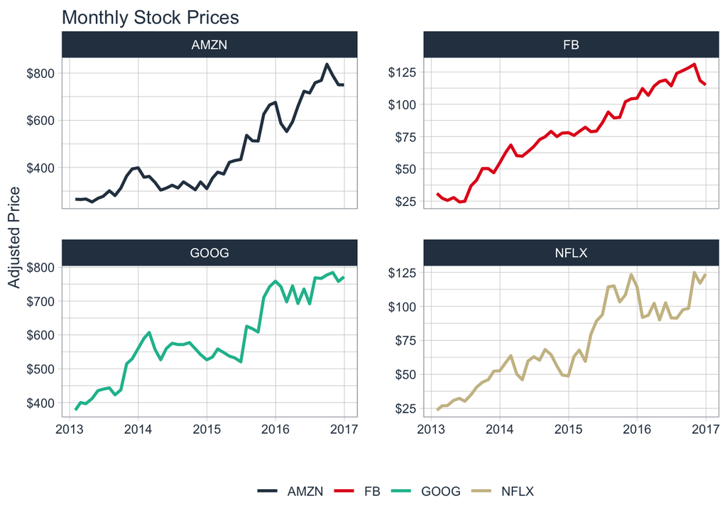

```r
FANG_monthly <- FANG %>%
  group_by(symbol) %>%
  tq_transmute( select = adjusted,
                mutate_fun = to.period,
                period= "months")

FANG_monthly %>%
  ggplot(aes(x = date, y = adjusted, color=symbol))+
  geom_line(size =1)+
  labs(title="Monthly Stock Prices",
       x="", y ="Adjusted Price", color="")+
  facet_wrap (~ symbol, ncol=2, scales = "free_y")+
  scale_y_continuous(labels = scales::dollar) +
  theme_tq()+
  scale_color_tq()
```

**낮은 수준에서 높은 수준으로 주기성을 높일 경우 smooth한 그래프를 얻을 수 있음.**

### Example 3: Use TTR `runCor` to Visualize Rolling Correlations of Returns

**이동 상관계수(rolling correlation): 시간의 흐름에 따른 자산 간 상관계수의 변화를 확인할 수 있다.**  
이동 상관계수는 두 자산간 움직임을 측정하는데 반해 CS는 여러 자산 으로 구성된 포트폴리오의 변화를 측정하는 점에서 다르다.

- Correlation surprise(CS) : 과거 상관계수 대비 자산간 움직임의 비정상 정도를 측정

수익률 상관 관계는 자산이나 포트폴리오가 기준 지수나 펀드를 얼마나 가깝게 모방하는지 분석하는 일반적인 방법.

- baseline 값으로 XLK 값 사용
- XLK : Technology Select Sector SPDR Fund, 미국 IT 기술주
- 관련된 내용 : https://strikebell.tistory.com/74
- `tq_get()` 을 사용하여 “XLK” 가격 가져옴.

```r
# Asset Returns
FANG_returns_monthly <- FANG %>%
  group_by(symbol) %>%
  tq_transmute(select = adjusted,
               mutate_fun = periodReturn,
               period = "monthly") # xts 함수의 주기성 월 지정 : months

# Baseline Returns
baseline_returns_monthly <- "XLK" %>%
  tq_get(get = "stock.prices",
         from = "2013-01-01",
         to = "2016-12-31") %>%
  tq_transmute(select = adjusted,
               mutate_fun = periodReturn,
               period="monthly")

baseline_returns_monthly
```

```
## # A tibble: 48 x 2
##    date       monthly.returns
##    <date>               <dbl>
##  1 2013-01-31        -0.0138
##  2 2013-02-28         0.00782
##  3 2013-03-28         0.0258
##  4 2013-04-30         0.0175
##  5 2013-05-31         0.0279
##  6 2013-06-28        -0.0289
##  7 2013-07-31         0.0373
##  8 2013-08-30        -0.0104
##  9 2013-09-30         0.0253
## 10 2013-10-31         0.0502
## # … with 38 more rows
```

FANG return 값과 XLK 값을 JOIN

```r
returns_joined <- left_join(FANG_returns_monthly,
                            baseline_returns_monthly,
                            by = "date")
returns_joined
```

```
## # A tibble: 192 x 4
## # Groups:   symbol [4]
##    symbol date       monthly.returns.x monthly.returns.y
##    <chr>  <date>                 <dbl>             <dbl>
##  1 FB     2013-01-31          0.106             -0.0138
##  2 FB     2013-02-28         -0.120              0.00782
##  3 FB     2013-03-28         -0.0613             0.0258
##  4 FB     2013-04-30          0.0856             0.0175
##  5 FB     2013-05-31         -0.123              0.0279
##  6 FB     2013-06-28          0.0218            -0.0289
##  7 FB     2013-07-31          0.479              0.0373
##  8 FB     2013-08-30          0.122             -0.0104
##  9 FB     2013-09-30          0.217              0.0253
## 10 FB     2013-10-31         -0.000398           0.0502
## # … with 182 more rows
```

The `TTR::runCor` function can be used to evaluate rolling correlations using the xy pattern.

- `n = ?` 을 지정하여 롤링 상관계수의 크기를 지정 가능.
- y : basement return 값

```r
FANG_rolling_corr <- returns_joined %>%
  tq_transmute_xy(x = monthly.returns.x,
                  y = monthly.returns.y,
                  mutate_fun = runCor,
                  n = 6, # 6개월
                  col_rename = "rolling.corr.6")

FANG_rolling_corr
```

```
## # A tibble: 192 x 3
## # Groups:   symbol [4]
##    symbol date                rolling.corr.6
##    <chr>  <dttm>                       <dbl>
##  1 FB     2013-01-31 00:00:00         NA
##  2 FB     2013-02-28 00:00:00         NA
##  3 FB     2013-03-28 00:00:00         NA
##  4 FB     2013-04-30 00:00:00         NA
##  5 FB     2013-05-31 00:00:00         NA
##  6 FB     2013-06-28 00:00:00         -0.519
##  7 FB     2013-07-31 00:00:00          0.325
##  8 FB     2013-08-30 00:00:00          0.235
##  9 FB     2013-09-30 00:00:00          0.396
## 10 FB     2013-10-31 00:00:00          0.185
## # … with 182 more rows
```

**FANG 조정 주가에 대한 6개월 간의 ROLLING CORRELATION 값 그래프**

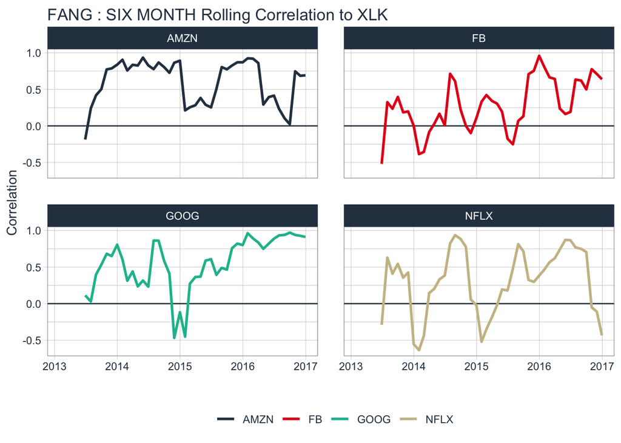

```r
FANG_rolling_corr %>%
  ggplot(aes(x = date, y = rolling.corr.6, color = symbol)) +
  geom_hline(yintercept = 0, color= palette_light()[[1]]) +
  geom_line(size =1)+
  labs ( title = "FANG : SIX MONTH Rolling Correlation to XLK",
         x ="", y ="Correlation", color="") +
  facet_wrap(~ symbol, ncol =2 )+
  theme_tq()+
  scale_color_tq()
```

### Example 4: Use TTR MACD to Visualize Moving Average Convergence Divergence

MACD : Moving Average Convergence Divergence, 이동평균의 수렴/확산

- Moving Average (이동평균) : 전체 데이터 집합의 여러 하위 집합에 대한 일련의 평균을 만들어 데이터 요소를 분석하는 계산 ( = 이동산술평균 (Moving Mean) 또는 롤링산술평균(Rolling Mean) )
- MACD : https://www.investopedia.com/terms/m/macd.asp
- Form : MACD(x, nFast = 12, nSlow = 26, nSig = 9, maType, percent = TRUE, …)
- MACD 함수 설명 : http://finzi.psych.upenn.edu/R/library/TTR/html/MACD.html

```r
FANG_macd <- FANG %>%
  group_by(symbol) %>%
  tq_mutate(select = close,
            mutate_fun = MACD,
            nFast = 12,
            nSlow = 26,
            nSig= 9,
            maType=SMA) %>% #SMA : Simple moving average
  mutate (diff = macd - signal) %>%
  select(-(open:volume))

FANG_macd
```

```
## # A tibble: 4,032 x 6
## # Groups:   symbol [4]
##    symbol date       adjusted  macd signal  diff
##    <chr>  <date>        <dbl> <dbl>  <dbl> <dbl>
##  1 FB     2013-01-02     28      NA     NA    NA
##  2 FB     2013-01-03     27.8    NA     NA    NA
##  3 FB     2013-01-04     28.8    NA     NA    NA
##  4 FB     2013-01-07     29.4    NA     NA    NA
##  5 FB     2013-01-08     29.1    NA     NA    NA
##  6 FB     2013-01-09     30.6    NA     NA    NA
##  7 FB     2013-01-10     31.3    NA     NA    NA
##  8 FB     2013-01-11     31.7    NA     NA    NA
##  9 FB     2013-01-14     31.0    NA     NA    NA
## 10 FB     2013-01-15     30.1    NA     NA    NA
## # … with 4,022 more rows
```

**2016년 10월 1일 이후 이동평균 그래프**

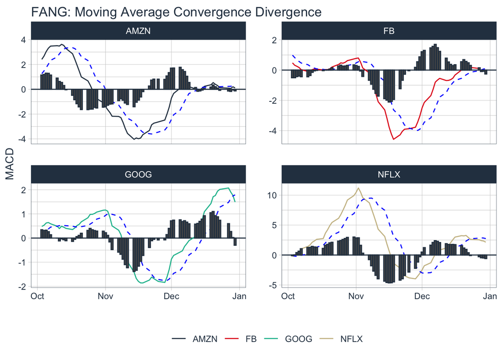

```r
FANG_macd %>%
    filter(date >= as_date("2016-10-01")) %>%
    ggplot(aes(x = date)) +
    geom_hline(yintercept = 0, color = palette_light()[[1]]) +
    geom_line(aes(y = macd, col = symbol)) +
    geom_line(aes(y = signal), color = "blue", linetype = 2) +
    geom_bar(aes(y = diff), stat = "identity", color = palette_light()[[1]]) +
    facet_wrap(~ symbol, ncol = 2, scale = "free_y") +
    labs(title = "FANG: Moving Average Convergence Divergence",
         y = "MACD", x = "", color = "") +
    theme_tq() +
    scale_color_tq()
```

### Example 5: Use xts `apply.quarterly` to Get the Max and Min Price for Each Quarter

The `xts::apply.quarterly()` function that is part of the period apply group can be used to apply functions by quarterly time segments.

- 분기별로 통계량 계산 등 함수 적용 가능.
- FUN = max : 최대값, FUN = min : 최소값

```r
# 분기별 최대값
FANG_max_by_qtr <- FANG %>%
  group_by(symbol) %>%
  tq_transmute( select = adjusted,
                mutate_fun = apply.quarterly,
                FUN = max,
                col_rename = "max.close") %>%
  mutate(year.qtr = paste0(year(date), "-Q", quarter(date))) %>%
  #paste0은 나열된 원소 사이에 공백없이 출력
  select(-date)

FANG_max_by_qtr
```

```
## # A tibble: 64 x 3
## # Groups:   symbol [4]
##    symbol max.close year.qtr
##    <chr>      <dbl> <chr>
##  1 FB          32.5 2013-Q1
##  2 FB          29.0 2013-Q2
##  3 FB          51.2 2013-Q3
##  4 FB          58.0 2013-Q4
##  5 FB          72.0 2014-Q1
##  6 FB          67.6 2014-Q2
##  7 FB          79.0 2014-Q3
##  8 FB          81.4 2014-Q4
##  9 FB          85.3 2015-Q1
## 10 FB          88.9 2015-Q2
## # … with 54 more rows
```

```r
# 분기별 최소값
FANG_min_by_qtr <- FANG %>%
  group_by(symbol) %>%
  tq_transmute( select = adjusted,
                mutate_fun = apply.quarterly,
                FUN = min,
                col_rename = "min.close") %>%
  mutate(year.qtr = paste0(year(date), "-Q", quarter(date))) %>%
  #paste0은 나열된 원소 사이에 공백없이 출력
  select(-date)

FANG_min_by_qtr
```

```
## # A tibble: 64 x 3
## # Groups:   symbol [4]
##    symbol min.close year.qtr
##    <chr>      <dbl> <chr>
##  1 FB          25.1 2013-Q1
##  2 FB          22.9 2013-Q2
##  3 FB          24.4 2013-Q3
##  4 FB          44.8 2013-Q4
##  5 FB          53.5 2014-Q1
##  6 FB          56.1 2014-Q2
##  7 FB          62.8 2014-Q3
##  8 FB          72.6 2014-Q4
##  9 FB          74.1 2015-Q1
## 10 FB          77.5 2015-Q2
## # … with 54 more rows
```

분기별 최대값, 최소값 data frames 생성

```r
FANG_by_qtr <- left_join(FANG_max_by_qtr, FANG_min_by_qtr,
                         by = c("symbol" = "symbol",
                                "year.qtr" = "year.qtr"))

FANG_by_qtr
```

```
## # A tibble: 64 x 4
## # Groups:   symbol [4]
##    symbol max.close year.qtr min.close
##    <chr>      <dbl> <chr>        <dbl>
##  1 FB          32.5 2013-Q1       25.1
##  2 FB          29.0 2013-Q2       22.9
##  3 FB          51.2 2013-Q3       24.4
##  4 FB          58.0 2013-Q4       44.8
##  5 FB          72.0 2014-Q1       53.5
##  6 FB          67.6 2014-Q2       56.1
##  7 FB          79.0 2014-Q3       62.8
##  8 FB          81.4 2014-Q4       72.6
##  9 FB          85.3 2015-Q1       74.1
## 10 FB          88.9 2015-Q2       77.5
## # … with 54 more rows
```

**분기별 최대값과 최소값 그래프**

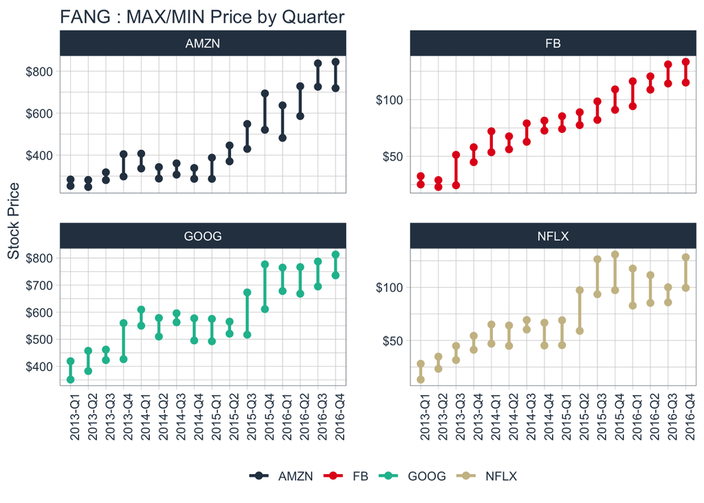

```r
FANG_by_qtr %>%
  ggplot(aes(x = year.qtr, color = symbol)) +
  geom_segment(aes(xend = year.qtr, y = min.close, yend = max.close),
               size = 1)+
  geom_point(aes(y=max.close), size=2)+
  geom_point(aes(y=min.close), size=2)+
  facet_wrap(~ symbol, ncol=2, scale = "free_y")+
  labs(title="FANG : MAX/MIN Price by Quarter",
       y = "Stock Price", color = "") +
  theme_tq()+
  scale_color_tq()+
  scale_y_continuous(labels=scales::dollar)+
  theme(axis.text.x = element_text(angle = 90, hjust =1), # 격자무늬 배경
        axis.title.x = element_blank())
```

### Example 6: Use zoo rollapply to visualize a rolling regression

A good way to analyze relationships over time is using rolling calculations that compare two assets.  
시간의 흐름에 따른 관계를 분석하기에 두 자산을 비교하는 롤링 계산을 이용하는 것이 제일 효과적이다.

In this example we will analyze two similar assets, Mastercard (MA) and Visa (V) to show the relationship via regression.

- `tq_get()`을 활용하여 마스터카드(MA)와 비자(V)의 2년간(2015년 ~ 2016년)의 주가 데이터를 수집

```r
#Get Stock pairs
stock_prices <- c("MA", "V") %>%
  tq_get(get = "stock.prices",
         from = "2015-01-01",
         to = "2016-12-31") %>%
  group_by(symbol)

stock_prices
```

```
## # A tibble: 1,008 x 8
## # Groups:   symbol [2]
##    symbol date        open  high   low close  volume adjusted
##    <chr>  <date>     <dbl> <dbl> <dbl> <dbl>   <dbl>    <dbl>
##  1 MA     2015-01-02  86.7  87.4  84.9  85.7 4505800     82.5
##  2 MA     2015-01-05  85.3  85.3  83.1  83.3 6441400     80.2
##  3 MA     2015-01-06  83.7  83.8  81.8  83.1 7690000     80.0
##  4 MA     2015-01-07  84.1  84.3  83.1  84.2 5846800     81.3
##  5 MA     2015-01-08  85.2  85.6  85.0  85.5 5174200     82.5
##  6 MA     2015-01-09  86.0  86    84.4  84.4 4582200     81.5
##  7 MA     2015-01-12  84.4  84.8  82.9  83.4 4030100     80.4
##  8 MA     2015-01-13  84.1  85.2  82.7  83.6 4222100     80.6
##  9 MA     2015-01-14  82    83.5  81.8  83.5 5084300     80.5
## 10 MA     2015-01-15  83.8  84.1  82.2  82.2 4331500     79.4
## # … with 998 more rows
```

```r
stock_pairs <- stock_prices %>%
  tq_transmute ( select = adjusted,
                 mutate_fun = periodReturn,
                 period = "daily",
                 type= "log",
                 col_rename = "returns") %>%
  spread(key = symbol, value = returns) # 세로형 -> 가로형 데이터

stock_pairs
```

```
## # A tibble: 504 x 3
##    date             MA        V
##    <date>        <dbl>    <dbl>
##  1 2015-01-02  0        0
##  2 2015-01-05 -0.0285  -0.0223
##  3 2015-01-06 -0.00216 -0.00646
##  4 2015-01-07  0.0154   0.0133
##  5 2015-01-08  0.0154   0.0133
##  6 2015-01-09 -0.0128  -0.0149
##  7 2015-01-12 -0.0129  -0.00196
##  8 2015-01-13  0.00228  0.00292
##  9 2015-01-14 -0.00108 -0.0202
## 10 2015-01-15 -0.0146  -0.00955
## # … with 494 more rows
```

**마스터카드와 비자의 관계 그래프**

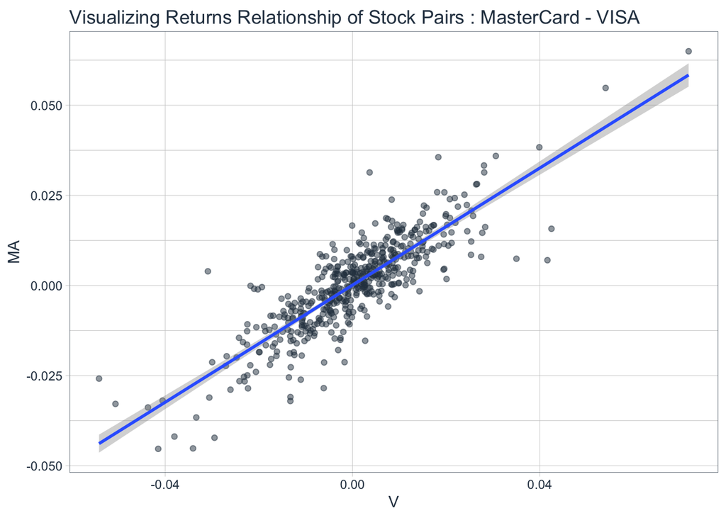

```r
stock_pairs %>%
  ggplot(aes(x = V, y=MA))+
  geom_point(color = palette_light()[[1]], alpha =0.5)+
  geom_smooth(method = "lm") + # lm function
  labs(title = "Visualizing Returns Relationship of Stock Pairs : MasterCard - VISA")+
  theme_tq()
```

lm (linear Regression) 함수를 사용하여 두 자산 사이의 관계에 대한 통계값을 구할 수 있음.

```r
lm(MA ~ V, data = stock_pairs ) %>%
  summary()
```

```
##
## Call:
## lm(formula = MA ~ V, data = stock_pairs)
##
## Residuals:
##        Min         1Q     Median         3Q        Max
## -0.0268888 -0.0039709  0.0002264  0.0039568  0.0289152
##
## Coefficients:
##              Estimate Std. Error t value Pr(>|t|)
## (Intercept) 0.0001014  0.0003101   0.327    0.744
## V           0.8119860  0.0226457  35.856   <2e-16 ***
## ---
## Signif. codes:  0 '***' 0.001 '**' 0.01 '*' 0.05 '.' 0.1 ' ' 1
##
## Residual standard error: 0.00696 on 502 degrees of freedom
## Multiple R-squared:  0.7192, Adjusted R-squared:  0.7186
## F-statistic:  1286 on 1 and 502 DF,  p-value: < 2.2e-16
```

- Coefficients 의 Estimate 값이 0.812, **p-value < 0.05** 으로 둘 사이의 관계성이 없다는 귀무가설을 기각하고 둘 사이에는 긍정적인 관계성이 존재함을 확인 가능.
- V의 주가가 증가할 경우 MA의 주가도 증가하는 경향이 있음.
- 하지만 이러한 관계는 시간적 측면을 고려하지 못함. -> `zoo::rollapply` 를 사용하여 Rolling Regression 계산

##### Rolling Regression 계산을 위한 STEP with `tq_mutate()`

1. Create a custom function 이때 중요한 것은 데이터의 형태가 `xts`의 객체로 전달되어야 하기 때문에 `timetk::tk_tbl`로 데이터를 변환하여 전달

```r
regr_fun <- function(data){
  coef(lm(MA ~ V, data = timetk::tk_tbl(data, silent = TRUE)))
}
```

2. Apply the function with `tq_mutate(mutate_fun = rollapply)` `by.column = FALSE` 로 각 열이 아닌 전체 데이터에 함수가 적용되어 계산될 수 있도록 지정해주어야 함!

```r
stock_pairs <- stock_pairs %>%
  tq_mutate(mutate_fun=rollapply,
            width = 90, #90일 간격
            FUN = regr_fun,
            by.column = FALSE,
            col_rename = c("coef.0", "coef.1"))
stock_pairs
```

```
## # A tibble: 504 x 5
##    date             MA        V coef.0 coef.1
##    <date>        <dbl>    <dbl>  <dbl>  <dbl>
##  1 2015-01-02  0        0           NA     NA
##  2 2015-01-05 -0.0285  -0.0223      NA     NA
##  3 2015-01-06 -0.00216 -0.00646     NA     NA
##  4 2015-01-07  0.0154   0.0133      NA     NA
##  5 2015-01-08  0.0154   0.0133      NA     NA
##  6 2015-01-09 -0.0128  -0.0149      NA     NA
##  7 2015-01-12 -0.0129  -0.00196     NA     NA
##  8 2015-01-13  0.00228  0.00292     NA     NA
##  9 2015-01-14 -0.00108 -0.0202      NA     NA
## 10 2015-01-15 -0.0146  -0.00955     NA     NA
## # … with 494 more rows
```

**Coefficient 계수 그래프**

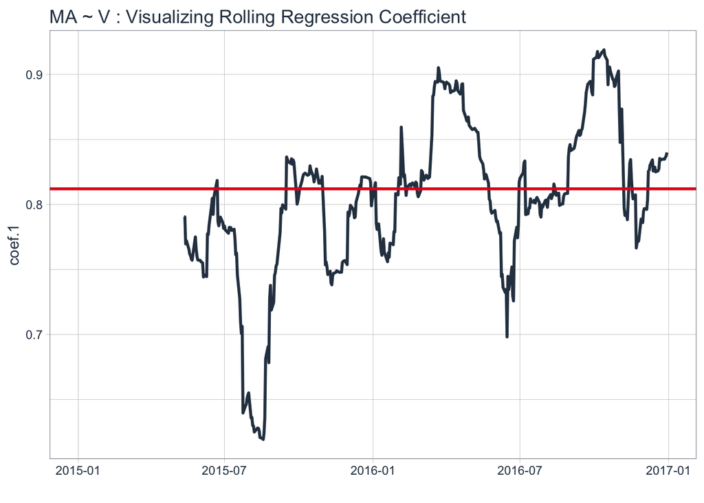

```r
stock_pairs %>%
  ggplot(aes(x=date, y = coef.1)) +
  geom_line(size =1, color =palette_light()[[1]])+
  geom_hline(yintercept = 0.812, size = 1, color = palette_light()[[2]]) +
  labs(title = "MA ~ V : Visualizing Rolling Regression Coefficient", x ="")+
  theme_tq()
```

**기간동안의 주가 그래프**

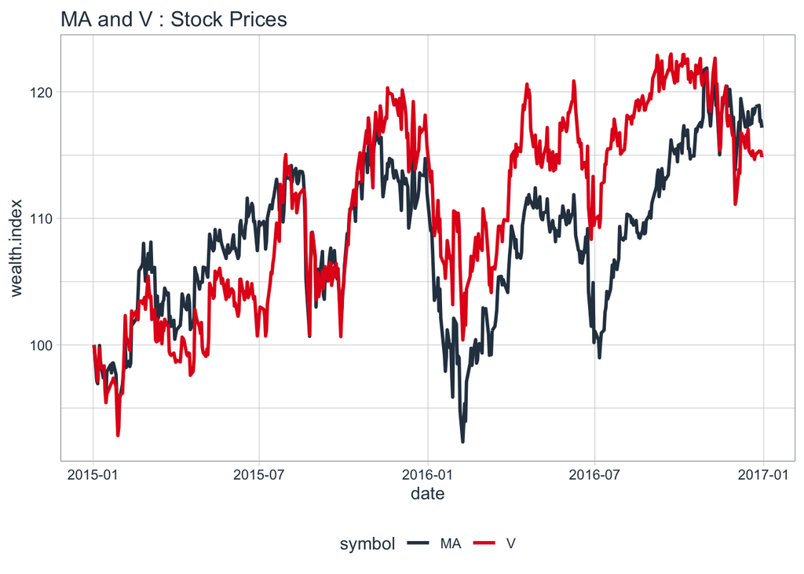

```r
stock_prices %>%
  tq_transmute(adjusted,
               periodReturn,
               period = "daily",
               type = "log",
               col_rename="returns") %>%
  mutate(wealth.index = 100 * cumprod(1 + returns)) %>% # cumprod : Cumulative Products : 누적곱
  ggplot(aes(x = date, y= wealth.index, color = symbol)) +
  geom_line(size =1) +
  labs( title ="MA and V : Stock Prices")+
  theme_tq()+
  scale_color_tq()
```

### Example 7: Use `Return.clean` and `Return.excess` to clean and calculate excess returns

1. we calculate daily returns using `quantmod::periodReturn`.
2. we use Return. clean to clean outliers from the return data. The alpha parameter is the percentage of oultiers to be cleaned.
3. The excess returns are calculated using a risk-free rate of 3% (divided by 252 for 252 trade days in one year).
- `Return.clean` : 이상치를 제거하기 위한 함수, alpha 값을 통해 이상치의 정도를 지정 가능.  
  http://braverock.com/brian/R/PerformanceAnalytics/html/Return.clean.html
- `Return.excess` : 위험 부담율을 초과하는 자산의 수익을 측정. http://braverock.com/brian/R/PerformanceAnalytics/html/Return.excess.html

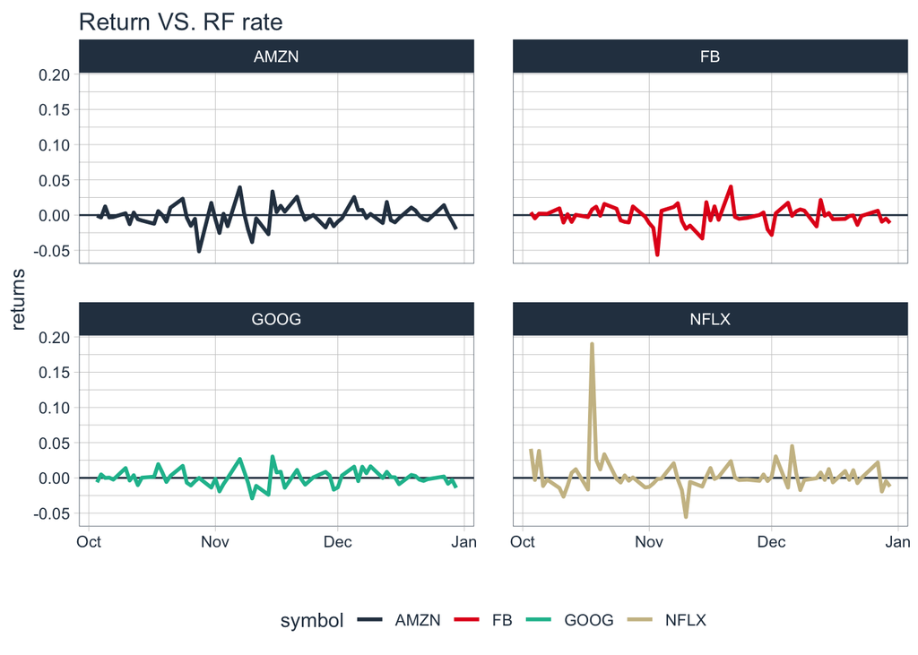

```r
FANG %>%
    group_by(symbol) %>%
    tq_transmute(adjusted, periodReturn, period = "daily") %>%
    tq_transmute(daily.returns, Return.clean, alpha = 0.05) %>%
    tq_transmute(daily.returns, Return.excess,
                 Rf = 0.03 / 252, col_rename ="returns") %>%
    filter(date >= as_date("2016-10-01")) %>%
    ggplot(aes(x = date, y=returns, color = symbol)) +
    geom_hline(yintercept=0, color=palette_light()[[1]]) +
    geom_line(size = 1) +
    facet_wrap(~ symbol, ncol = 2) +
    labs(title = "Return VS. RF rate", x="")+
    theme_tq()+
    scale_color_tq()
```